# SPILLOVER EFFECTS OF MASS LAYOFFS

Converted from PDF `Gathmann-MassLayoffSpillovers-2020-JEEA.pdf` · 42 pages · anchors: page `#pN`, block `#pN-bK`

Page 1

### **SPILLOVER EFFECTS OF MASS LAYOFFS**

**Christina Gathmann** University of Heidelberg

**Ines Helm** Stockholm University

**Uta Sch¨onberg** University College London and Institute for Employment Research

**Abstract** Using administrative data on firms and workers in Germany, we quantify the spillover effects of mass layoffs. Our empirical strategy combines matching with an event study approach to trace employment and wages in regions hit by a mass layoff relative to suitable control regions. We find sizable and persistent negative spillover effects on the regional economy: regions, and especially firms producing in the same broad industry as the layoff plant, lose many more jobs than in the initial layoff. In contrast, negative employment effects on workers employed in the region at the time of the mass layoff are considerably smaller. Strikingly, workers younger than 50 suffer no employment losses, as geographic mobility fully shields them from the decline in local employment opportunities. (JEL: J21, J31, J61, J63, R12)

#### **1. Introduction**

Governments are often willing to subsidize or bail out firms on the verge of bankruptcy. The Bush and the Obama administration provided in total over US $50 billion to General Motors and Chrysler to prevent the shut-down of plants during the Great Recession. In Europe, both the British and German governments tried to ensure that a new Opel/Vauxhall model would be produced in their own country thus preventing plant closures in 2012. Similarly, place-based policies like the European Regional Development Fund, with an annual budget of around €50 billion, subsidize regions lagging behind and firms in distress to avoid mass layoffs and regional decline.

*The editor in charge of this paper was Claudio Michelacci.*

Acknowledgments: Financial support from the German Science Foundation within the Priority Programme SPP 1764 “The German Labor Market in a Globalized World: Challenges through Trade, Technology, and Demographics” and from the European Research Council through the ERC Starting Grant “Identifying Spillovers in the Labor Market (SPILL)” is gratefully acknowledged.

E-mail: christina.gathmann@awi.uni-heidelberg.de (Gathmann); ines.helm@ne.su.se (Helm); u.schoenberg@ucl.ac.uk (Sch¨onberg)

*Journal of the European Economic Association* 2020 18(1):427–468 DOI: 10.1093/jeea/jvy045 c The Author(s) 2018. Published by Oxford University Press on behalf of European Economic Association. All rights reserved. For permissions, please e-mail: journals.permissions@oup.com

Page 2

428 Journal of the European Economic Association

The main economic rationale behind these interventions is that a mass layoff in or a closure of a large “flagship” firm—a firm that is considerably larger and pays higher wages than the average firm in the region and is thus important to the local labor market—would not only harm workers in that plant, but create a domino effect on the region as a whole, thereby multiplying job losses.<sup>1</sup> Such domino effects may occur if massive job destruction in a region reduces consumer demand in local goods and services (such as restaurants, cleaning services, or retail) through local multiplier effects. Agglomeration economies may be an alternative explanation for spillover effects. Firms in the same local economy may lose some of their productivity or cost advantages of locating in larger or denser areas following a mass layoff. The decline in the size of the local economy may, for instance, reduce knowledge spillovers or the quality of job matches between workers and firms, thus triggering additional job losses. Employment in the region may also decline because local firms that are connected to the mass layoff firm through input–output linkages may temporarily face a decline in product demand.

Yet, how important are such spillover effects to the local economy? Can massive job destruction in one plant really trigger a domino effect resulting in the economic decline of a whole region? And are these spillovers mostly the consequence of local multipliers, or of agglomeration effects? Our empirical analysis sheds light on these important questions.

We then ask how local economies adjust following mass job destruction; and what the adjustment implies for local workers who were employed in the region at the time of the mass layoff. Local employment may adjust to a mass layoff in various ways. According to one scenario—the one that appears to dominate the public debate—a decline in local employment may primarily result in higher local un- or nonemployment rates: workers who were previously employed in the affected region may become unemployed, or workers who were previously unemployed may fail to find jobs. According to an alternative, much more optimistic scenario, local employment declines primarily reflect shifts in employment across regions, with little impact on un- or nonemployment. The two scenarios have very different implications for the welfare of local workers: Whereas in the former scenario, the potential welfare losses from mass layoffs may be severe, welfare losses for local workers in the latter case are limited by their geographical mobility.

To quantify spillover effects empirically, we require unusually rich data with detailed annual information on local labor markets. Our administrative data from Germany that contain all workers and firms covered by the social security system over more than three decades are uniquely suited for this purpose. Based on unique identifiers for plants and workers, we can identify mass layoffs and plants located in the same local labor market, and follow workers as they move to other regions. We define a mass layoff as a reduction in plant size in the tradable sector by at least 500 employees.

1. Throughout this paper, we will use plant and firm interchangeably as our data do not allow us to separate between the two.

Page 3

Gathmann, Helm, and Sch¨onberg Spillover Effects of Mass Layoffs 429

Anecdotal evidence points to mismanagement and offshoring of jobs abroad as two leading explanations for the mass layoffs. By construction, mass layoffs in our sample occur in very large plants (employing 8,123 workers on average) that pay substantially higher wages (27%) than the average plant in the local economy—exactly the type of firms that feature in the policy debate and that governments are willing to subsidize (or punish) to prevent mass layoffs. On average, a mass layoff in our sample reduces employment in a district by about 1,700 jobs or 1.9%.

Our empirical strategy combines matching with an event study approach to flexibly compare employment and wages in regions hit by a mass layoff with employment and wages in suitable control regions. Mass layoff regions may evolve differently from other regions simply because of (correlated) industry-specific shocks that reduce employment in the mass layoff firm as well as in other firms operating in the same (or a related) industry. Our matching procedure therefore chooses control regions with an industry structure similar to the mass layoff regions in the years prior to the event. Additional estimates show that our results are unchanged if we allow for industryspecific employment trends by including 2- or 3-digit industry-by-year fixed effects in our regressions.

Despite the large number of jobs lost to the region following the mass layoff, employment prospects of workers who were employed in the region at the time of the mass layoff are hampered much less (and decline by only 0.8 percentage points four years after the mass layoff). Moreover, these individual employment losses are

Page 4

430 Journal of the European Economic Association

heavily concentrated among workers older than 50: whereas older workers suffer sharp and persistent reductions in their employment probabilities of 3.4 percentage points four years after the mass layoff, employment prospects of workers younger than 50 are hardly affected. Geographic mobility nearly fully shields them from the decline in local employment opportunities, as they relocate to find employment in other regions and inflows to the region decrease. Older workers, in contrast, relocate very seldom to other regions and therefore suffer most from the declining employment opportunities in the local economy.

Our study is related to four strands of the literature. A long line of research has documented that workers who lose their job because of a mass layoff or plant closure suffer long-lasting earnings losses. Early studies for the United States include Ruhm (1991a,b), and Jacobson et al. (1993); recent studies for Europe include Eliason and Storrie (2006), Huttunen et al. (2011), and Schmieder et al. (2009). The existing literature focuses almost exclusively on the consequences for those directly affected by the displacement. Our study is the first that provides a comprehensive analysis of how mass job destruction in large flagship firms affect the region, and the workers in the region, as a whole.<sup>2</sup>

Our study also adds to the literature on agglomeration forces, one of the reasons why displacement effects may spill over to the local labor market. A number of recent studies exploit (as we do) arguably exogenous variation in local density to identify agglomeration effects, caused by, for instance, the arrival of a large plant (Greenstone et al. 2010); shocks due to trade integration (Helm 2017); the inflow of local public investments following place-based policies (Kline and Moretti 2014);<sup>3</sup> or the construction of large-scale hydroelectric dams (Severnini 2014).<sup>4</sup> Although Severnini (2014) and Kline and Moretti (2014) adopt a long-term perspective investigating events that happened more than five decades ago, Helm (2017) and Greenstone et al. (2010) focus, as we do, on the short-term effects. Greenstone et al. (2010) find that five

2. Two recent studies analyze the potential indirect effects of plant closures (Vom Berge and Schmillen 2015; Jofre-Monseny et al. 2018). Vom Berge and Schmillen (2015) analyze plants with at least 100 employees and focus on spillover effects within 0.5 km of the location of the event plant (using plants located outsides this radius as controls). Jofre-Monseny et al. (2018) study plant closures in manufacturing plants with at least 100 workers (the median layoff size is 264). Both studies do not find evidence for spillover effects. A potential reason is that both studies focus on much smaller employment shocks, which makes it more difficult to identify spillover effects statistically. Further, spillover effects might only emerge for mass layoffs above a certain size. Our findings suggest that spillover effects tend to get smaller when analyzing mass layoffs with a smaller size restriction (see Tables A.1 and A.2 in the Online Appendix, column (2) for mass layoffs with at least 300 workers).

3. Other studies of place-based policies have at least in part been motivated by the existence of agglomeration spillovers, such as the Federal Empowerment Zones in the United States (Busso et al. 2013), regional subsidy programs in France (Gobillon et al. 2012), Italy (Bronzini and de Blasio 2012), the United Kingdom (Criscuolo et al. 2012) or Germany (von Ehrlich and Seidel 2018); and the European Structural Funds (Becker et al. 2010; Becker et al. 2013).

4. Earlier work has focused on the relationship between city (or local industry) size or density and productivity more generally (see, e.g., Ciccone and Hall 1996 for a seminal contribution and Rosenthal and Strange 2004 for a survey).

Page 5

Gathmann, Helm, and Sch¨onberg Spillover Effects of Mass Layoffs 431

years after the opening of the plant, total factor productivity of incumbent plants in the manufacturing sector substantially increases in counties that attracted a large manufacturing plant compared to counties that were the runner-up choice. Instead of analyzing the (positive) spillover effects of plant openings, we investigate the (potentially negative) spillover effects of massive job destruction. A second important difference is that we focus on employment and wages that are at the heart of the policy debate on bailout programs and regional subsidies. We further provide novel evidence of whether local employment adjusts to the job losses through the reallocation of workers across local labor markets or an increase in un- or nonemployment.

An alternative reason why displacement effects may spill over to the local economy are local multiplier effects: a decline in local employment and wages may reduce consumer demand for local goods and services and therefore lead to lower employment in the nontradable sector. Recent research suggests that local multiplier effects may be sizable (see, e.g., Moretti 2010 for the United States; Moretti and Thulin 2013 for Sweden; and Faggio and Overman 2014 for the United Kingdom).<sup>5</sup> Our research relies on an alternative, plausibly exogenous shock to the local economy for identification and investigates, among other things, whether a mass layoff in the tradable sector harms the nontradable sector in the local economy.

Finally, our analysis also contributes to the literature on how labor markets respond to local demand shocks. Several studies document persistent differences in employment across regions following labor demand shocks—despite adjustments through worker mobility (see Topel 1986 and Blanchard and Katz 1992 for early contributions; Bound and Holzer 2000; Monras 2015; Notowidigdo 2013; Yagan 2018; or Amior and Manning 2018 for more recent studies). Our findings highlight that agglomeration economies and, to a lesser extent, local multipliers may be important reasons for the persistence of the decline in regional employment as many more jobs are lost to the region than in the initial mass layoff. We further show that both increased outflows out of the region and reduced inflows of workers into the region are important adjustment mechanisms to local shocks. Most importantly, our results underscore that a persistent decline in local employment does not necessarily imply that local workers suffer permanently. In our case, the mobility of younger workers nearly fully shields them against the negative consequences of mass layoffs on the local economy.

The paper is structured as follows. The next section sets out the theoretical mechanisms through which a mass layoff affects the regional economy and individuals in the local labor market. Section 3 describes the data and how we define mass layoff events. Section 4 introduces our matching approach to find suitable control regions and our empirical strategy to assess the effects of mass layoffs on regional economies. Section 5 contrasts the effects of mass layoffs on the local labor market with those on workers employed in these labor markets at the time of the mass layoff. Finally, Section 6 discusses the implications of our analysis and concludes.

5. Related work analyzes how local employment is affected by the withdrawal of military forces; see, for example, Aus dem Moore and Spitz-Oener (2012) or Zou (2014).

Page 6

432 Journal of the European Economic Association

#### **2. Theoretical Framework**

#### *2.1. Sources of Agglomeration Effects*

In most countries, economic activity is spatially concentrated, even though firms in economically dense areas typically face higher costs for labor and land.<sup>6</sup> Why then are firms willing to locate in these high-cost areas? As first hypothesized by Marshall (1890), a locational preference can be explained by productivity or cost advantages enjoyed by firms when they locate close to each other. A first reason for these locational advantages are input–output relations: firms may benefit from locating close to their downstream customers and upstream suppliers because of the cheaper and faster delivery of local services and intermediate goods.<sup>7</sup> Knowledge spillovers and human capital externalities provide a second reason why firms prefer to locate close to each other. Formal and informal interactions among individuals at work or in the neighborhood lead to knowledge sharing and learning, which may generate positive production externalities across workers (see, e.g., Marshall 1890; Lucas 1988; Jovanovic and Rob 1989; Glaeser 1999; Serafinelli 2013).<sup>8</sup> A third reason could be the thickness of the labor market. In a labor market with search frictions and heterogeneous firms and workers, worker-firm matches may be more productive when many firms offer jobs and many workers look for jobs in the same local labor market.<sup>9</sup>

All three reasons for agglomeration effects imply that a productivity decline in one firm, causing this firm to lay off a substantial share of its workforce, may reduce labor demand in other firms in the local labor market. If knowledge spillovers or thick labor market effects are responsible for the agglomeration economies, the decline in labor demand will be caused by a decline in total factor productivity. If input–output linkages are the source of agglomeration effects, firms’ total factor productivity remains unchanged. Instead, firms may demand less labor because they suffer a (possibly temporary) decline in product demand or an increase in transport costs.

We capture agglomeration effects in a reduced form as an area-specific productivity shifter *Ar* that we specify, as it is common in the literature (see, e.g., Greenstone et al. 2010 or Moretti 2011, Chap. 14), as a concave function of overall employment in the area, Ar D L

6. Hourly wages of white prime-aged men in the US metropolitan areas of more than 1.5 million people were 32% higher than in rural areas and small metropolitan areas of less than 250 thousand people (Baum-Snow and Pavan 2012).

7. Redding and Sturm (2008) provide indirect evidence on the importance of transport costs for economic development. They find that the population of West German cities located close to the East German border declined after Germany’s division due to reduced market access.

8. In related work, Moretti (2004b), Ciccone and Peri (2006), Moretti (2004a), or Acemoglu and Angrist (2000) estimate the importance of human capital externalities by relating the level of human capital in a city to firms’ total factor productivity or wages.

9. Large labor markets may in addition provide insurance against idiosyncratic shocks, for both firms and workers (see, e.g., Krugman 1991).

Page 7

Gathmann, Helm, and Sch¨onberg Spillover Effects of Mass Layoffs 433

by 1%, and is best thought of as reflecting all three sources of agglomeration effects discussed previously, including input–output linkages.

An alternative explanation why the productivity decline in one firm may spill over to other firms in the local economy is provided by local multiplier effects. A decline in local wages and employment caused by the mass layoff may reduce the demand for local goods and services thus reducing employment (and prices) in the nontradable sector. These effects will be reinforced in the presence of agglomeration effects in the tradable sector. We do not model local multiplier effects explicitly here, but investigate the response in the nontradable sector empirically in Section 5.2.2.

#### *2.2. Agglomeration Effects, Local Wages, and Employment*

How does a sharp decline in productivity in one firm affect wages and employment in the local labor market? In this section, we set up a simple theoretical framework to show that the local labor market effects do not only depend on the agglomeration elasticity , but also on other fundamental economic parameters, such as the local labor supply elasticity. We assume that all output produced in the local economy is sold in international markets at price *p* D 1; the local economy thus refers to the tradable sector only. We further assume that the local labor market under consideration is small relative to the national market. As a consequence, a local shock in the region will have no effect on equilibrium wages and employment in other regions, even if individuals move out of a region. For simplicity, we abstract from housing prices that also influence individual location decisions. Online Appendix A discusses an augmented version of our model with housing prices; this extension does not change the key implications of our model.

*Production Function.* Output *Y* in firm *j* located in area *r* is produced by combining labor *L* and capital according to a Cobb–Douglas production function. Following Glaeser and Gottlieb (2009), we distinguish between two types of capital, capital that is fixed at the firm level ( <sup>x</sup> K) and capital that is fully flexible (*K*):<sup>10</sup>

j K<sup>.1</sup><sup>˛/</sup>

j ; (1)

where is the share of fully flexible capital, *fj* is a firm-specific productivity shifter, and *Ar* is an area-specific productivity shifter capturing agglomeration forces: Ar D L

r <sup>.</sup> To ensure a unique local equilibrium, we impose an upper bound on the strength of agglomeration effects: < (1 ˛)(1 ).

10. We can think of fixed capital as a resource endowment or a specific location (proximity to the sea, e.g.); see Kline and Moretti (2014), Lee (2015), or Hanlon and Miscio (2017) for similar modeling assumptions. A fixed production factor ensures that regions may compete for the same firms in each period, even if other production factors like capital and labor are perfectly mobile.

Page 8

434 Journal of the European Economic Association

*Labor Supply.* Labor supply in area *r* depends on wages paid in that area (w*r*) and wages paid in other areas (w<sup>0</sup>

r<sup>):</sup>

Lr D f .wr; w<sup>0</sup>

r<sup>/:</sup> (2)

Let denote the inverse of the local labor supply elasticity (i.e., 1= D (*∂f*(.)=*∂*w*r*)(w*r*=*f*(.))). This elasticity captures the *local* employment response to *local* wages that combines several margins of adjustment, such as inflows or outflows of un- and nonemployment as well as movements across local economies. It thus differs from the labor supply elasticity typically estimated in the literature that measures the national labor supply response to changes in national wages.<sup>11</sup>

*Labor Demand at Baseline.* Firms choose labor *Lj* and flexible capital *Kj* to maximize profits, taking local productivity *Ar* and local wages w*r* as given. In a competitive equilibrium, production factors are paid their marginal product. Using the first-order conditions for capital and labor to solve for the firm’s labor demand curve (see Online Appendix A for derivations), aggregate labor demand is obtained by aggregating over all firms in the local labor market:<sup>12</sup>

log Lr D log

X

j

Lj

D log

X

j

f

Note that aggregate local labor demand is downward sloping with respect to wages as long as < (1 ˛)(1 ).<sup>13</sup>

*The Effect of a Firm-Specific Productivity Shock on Equilibrium Wages and Employment.* What happens to local labor demand if one firm in the market (the “event firm”) experiences an unexpected and persistent negative productivity shock?<sup>14</sup>

Based on its labor demand curve, the event firm responds to the decline in productivity by displacing workers: d log L*event* D df*event*=

< 0. If there are agglomeration forces at work, this mass layoff may trigger additional job losses in the

11. See, for example, Blundell et al. (2011) or Chetty et al. (2013) for recent surveys.

j

N Kj , which is fixed.

13. To see this, substitute log *Lr* for log *Ar* and solve equation (3) for log *Lr*. For existence of a stable equilibrium, we require the weaker condition: < (1 ˛)(1 ) C (1 (1 ˛)). If this condition does not hold, either all or no economic activity would be concentrated in the local labor market under consideration.

14. We model the shock here as a purely firm-specific shock. As we show in Section 3.2, the shocks that trigger the mass layoffs are a combination of aggregate shocks, industry-specific shocks, and firm-specific shocks. Our empirical strategy that we discuss in Section 4 uses only the firm-specific component of these shocks to estimate spillover effects.

Page 9

Gathmann, Helm, and Sch¨onberg Spillover Effects of Mass Layoffs 435

local economy through a decrease in labor demand (i.e., *d* log *Ar* D *d* log *Lr* < 0). There is, however, a counteracting force: firms (other than the event firm) will be willing to hire more labor if local wages go down in response to the productivity shock in the event firm. The overall effect on local labor demand can be obtained by totally differentiating the local demand curve (3) where we assume, for simplicity, that initially all firms in the local economy were equally productive, such that *fj* D 1 8 *j*:

:

(4)

A productivity decline in the event firm affects local labor demand through three forces: through the direct effect on the event firm’s labor demand (first term), through spillover effects on other firms (second term), and through endogenous wage adjustments (third term).

If wages are fully flexible, equilibrium wages and employment in the local economy are determined by the intersection of the local demand curve and the local labor supply curve. Using *d* log w*r* D *d* log *Lr* from the labor supply function (equation (2)), we can solve for the equilibrium employment and wage adjustments in the local economy:

J

d log wr D d log Lr: (6)

These equations show that a productivity decline in the event firm reduces both local employment and local wages. Both effects are increasing in the strength of agglomeration forces, . The elasticity of local labor supply, 1=, determines how much of the negative productivity shock in the event firm is absorbed through employment losses as opposed to wage reductions. If local labor supply is fully elastic (i.e., D 0), local wages are unchanged and the full adjustment occurs through a decline in local employment. If, in contrast, local labor supply is fully inelastic, local employment remains unchanged and only local wages decline. In the latter case, all workers displaced by the event firm would find a new job in other firms in the same region.

In reality, wages may not be fully flexible. In particular, it may be difficult to cut nominal wages because of constraints imposed by labor market institutions or other private contractual arrangements like collective bargaining agreements, for example (see Bauer et al. 2007 for Germany; and Dickens et al. 2007 for a survey). If wages do not fully adjust downward, the local economy will be demand-side constrained: some workers would like to work for the current wage rate, but cannot find a job in the local economy. Changes in local employment are still defined by equation (4), where the change on local wages *d* log w*r* is now determined exogenously by the degree of wage rigidity. If local wages do not adjust downward at all, the full adjustment to a negative productivity shock in the event firm is borne by local employment.

Page 10

436 Journal of the European Economic Association

*Indirect Employment Effects for Other Firms in the Region.* The negative productivity shock in the event firm reduces local employment and wages even if there are no agglomeration effects at work (i.e., if D 0). To isolate the effect of agglomeration forces from the standard general equilibrium adjustments, it is instructive to consider the employment adjustment in firms other than the event firm within the same local economy:

<sup>1</sup> <sup>.1</sup> <sup>˛/</sup>

C d log Lr .1 ˛/.1 / „ ƒ‚ …

:

agglomeration spillover ()

(7)

There are two opposing effects. On the one hand, local wages decline in response to the productivity decline in the event firm. In response, other firms in the same local economy are willing to employ some of the displaced workers (first term). On the other hand, if agglomeration forces are at work, their demand for labor also declines (second term). Hence, in the absence of agglomeration effects, employment in other firms in the region will increase as long as local labor supply is not infinitely elastic (or wages are not fully downward rigid). An observed decline in employment in other firms in the region, in contrast, indicates agglomeration effects that are large enough to dominate any positive effects through wage adjustments.

*Heterogeneous Effects by Industry.* Agglomeration forces should be particularly strong in firms that are economically close to the event firm. Let <sup>close</sup> and <sup>distant</sup>

denote the strength of the agglomeration effect in economically close and distant firms with <sup>close</sup> > <sup>distant</sup>. Further, assume that labor is perfectly mobile across firms and industries within the local labor market. Because of perfect labor mobility, the productivity shock in the event firm will affect wages in all firms and industries in the local labor market in the same way.<sup>15</sup> The negative agglomeration spillover in equation (7) however, will be stronger for firms that are economically close to the event firm.

*Adjustments in Local Employment.* The model focuses on the impact of firm-specific productivity shocks resulting in mass layoffs on local employment. Local employment may, however, adjust in various ways. A decline in local employment may primarily lead to higher un- or nonemployment rates: workers who were previously employed

15. This symmetry may not hold if workers can transfer more of their skills to close rather than distant industries so that labor is not freely mobile across industries within the local labor market. In that case, wages in close industries will decline more than wages in more distant industries. As a result, it becomes ambiguous which industry will experience a larger employment decline.

Page 11

Gathmann, Helm, and Sch¨onberg Spillover Effects of Mass Layoffs 437

in the region may face un- or nonemployment, or workers who were previously un- or nonemployed may fail to find new jobs. Alternatively, a decline in local employment may primarily reflect a reallocation of workers from declining to more prospering regions, with little effect on un- or nonemployment rates. Which adjustment mechanism dominates depends on workers’ attachment to a particular region, on the costs of geographic mobility, and on the unemployment or retirement benefits available, among others. We investigate the various adjustments mechanisms and the difference between adjustments at the local and the worker level in Section 5.3.

*Empirical Predictions.* To summarize, the theoretical framework yields four empirical predictions that we test with our data in what follows. First, a negative productivity shock that induces the event firm to shed labor reduces overall employment in the local economy. The shock also decreases employment in other firms in the same local economy provided that agglomeration spillovers are present and the negative effect of the agglomeration spillover dominates the positive effect from the wage adjustment in equilibrium. Second, the mass layoff puts a downward pressure on local wages. The size of the wage response is determined by the local labor supply elasticity or, alternatively, the degree of wage rigidity. Third, if agglomeration effects and not local multipliers are the dominant reason behind the local employment decline, employment losses will be concentrated in the tradable sector. Fourth, in the presence of agglomeration forces, employment declines will be more pronounced in firms that are economically close to the event firm such as firms producing in the same industry as the mass layoff firm.

#### **3. Data Sources and Definition of a Mass Layoff**

#### *3.1. Data Sources*

To study the spillover effects of mass layoffs empirically, we use German Social Security Records over more than three decades, from 1975 to 2008. The data comprise the population of workers and plants covered by the social security system in Germany; not included are the self-employed, civil servants and military personnel.<sup>16</sup>

We focus on West Germany since the East German economy underwent dramatic changes throughout the 1990s when transforming from a socialist to a market economy.

Three characteristics make this data set uniquely suited for the analysis of spillover effects. First, data on the population of workers and firms enable us to identify mass layoffs and distinguish them from breakups into multiple plants or other forms of restructuring (see the next section for details). Second, the data include detailed geographic information on firm location that is necessary to study spillover effects

16. In 1995, 79.4% of all workers in West Germany were covered by social security and are hence recorded in the data (Bundesagentur fuer Arbeit 1995).

Page 12

438 Journal of the European Economic Association

of mass layoffs on all other firms in the local economy. We study these spillovers at the district level. West Germany has 326 districts with about 60,000 jobs on average in our data. Districts roughly correspond to counties in the United States, the level of analysis in Greenstone et al. (2010). Third, using the panel structure of the data, we can track individuals even if they find employment in another district.

We observe for each individual whether she is employed within the social security system or whether she collects unemployment benefits as of June 30th each year. The wage variable, in contrast, records the average daily wage for the employment spell that contains this reference date.<sup>17</sup> Like most social security data, our wage variable is right-censored at the social security limit. We impute censored wages under the assumption that the error term in the wage regression is normally distributed, allowing for separate variances by district, year and gender. We deflate wages to 1995 prices using the consumer price index. Based on the universe of social security records, we also estimate a fixed firm and a fixed worker effect for each firm and worker in our sample (following Abowd et al. 1999; Card et al. 2013). We obtain these from (log) wage regressions over rolling 6-year windows additionally controlling for age, age squared, and year fixed effects.

We distinguish three skill groups. Low-skilled workers enter the labor market without post-secondary education; medium-skilled workers completed an apprenticeship or graduated from high school (*Abitur*). Workers are high-skilled if they graduated from a university or college. Finally, we restrict the analysis to individuals aged between 16 and 65. We also exclude irregular, marginal and seasonal employment. Our analysis of employment effects is based on workers in regular full- or part-time employment, where we reweight those in part-time employment (defined in our data as working less than 30 h per week) into full-time equivalent units by 0.6 (18–30 h) or 0.3 (less than 18 h). Our analysis of wage effects is based on full-time workers only.

#### *3.2. Definition of a Mass Layoff*

We want to identify a sharp, substantial and permanent reduction in plant size from one year to the next that presents a sizable shock to the local economy. Compared to the displacement literature that uses mass layoffs to identify exogenous job separations, we therefore require a much larger reduction in plant size. Specifically, we define a mass layoff as a decrease in plant size of at least 500 individuals for a minimum of two consecutive years. Our results are similar if we impose a weaker or stricter mass layoff definition of a reduction in plant size of at least 300 or 750 individuals instead (see columns (2) and (3) of Tables A.1 and A.2 or specification “layoff750” of Figure A.1 in the Online Appendix). If two mass layoffs occur within the same year, or in two consecutive years within the same plant, we combine them into a single event.<sup>18</sup>

17. Because employers are required to update records only at the end of each year, this variable may capture wage changes that occurred from January to December of the same year.

18. There are two cases in which two mass layoffs occur in two consecutive years in the same region, but in different firms. We also combine these mass layoffs into a single event.

Page 13

Gathmann, Helm, and Sch¨onberg Spillover Effects of Mass Layoffs 439

We focus on mass layoffs in the tradable sector where firms produce for the national or world market and are therefore, in the absence of agglomeration spillovers, not directly affected by local conditions like competitors located in the same local economy.<sup>19</sup> We further restrict the analysis to mass layoffs occurring between 1981 and 2004, so that we can trace regional development for at least four years prior to and four years after the mass layoff. To make sure that we capture a true mass layoff and not merely a change in the plant identifier or a spin-off, we impose the restriction that less than 30% of those leaving a plant go to a single other plant (Hethey and Schmieder 2010). To rule out breakups into multiple plants (which would not constitute a sizable shock to the local economy), we further require that not more than 70% of those leaving the plant go to the same three plants.

As our empirical strategy combines matching with an event study approach to trace outcomes in mass layoff regions relative to suitable control regions over time (see Section 4 for details), the mass layoff events should not be preceded by other large layoffs in the same region. We therefore exclude: (a) layoffs of more than 200 individuals in the two years prior to the mass layoff that together make up more than 50% of the original layoff; (b) other layoffs bigger than the original layoff in year 3 and 4 prior to the mass layoff (5 cases excluded); and (c) expansions bigger than the mass layoff in the first two years after the original mass layoff (2 cases excluded). These specific restrictions have little impact on our findings. In particular, our findings are unchanged if we impose the stricter restriction that no other layoffs affecting more than 200 individuals constituting at least 50% of the original layoff take place within four years (as opposed to two years as in restriction (a)) prior to the mass layoff (see specification “tmin4” in Figure A.1 and column (4) in Tables A.1 and A.2 in the Online Appendix); or if we completely remove restrictions (b) and (c) (see specification “onlyrestr_a” in Figure A.1 and column (5) in Tables A.1 and A.2 in the Online Appendix). Finally, we only keep events for which we can match a suitable control district (see Section 4.1 for details). Our final sample consists of 62 events taking place in 69 plants.

19. Mass layoffs in the nontradable sector may be beneficial for other firms in the local economy that operate in the same sector as the mass layoff firm as they can capture part of the market share of the layoff firm. This type of spillover effect is however, not the focus of this paper.

Page 14

440 Journal of the European Economic Association

TABLE 1. Characteristics of mass layoffs.

Panel A: Mass layoff events

[output not shown]

NOTE: table converted from PDF layout to HTML text; cell boundaries are reconstructed. See PDF if exact alignment matters.

Panel B: Mass layoff plants and displaced workers

[output not shown]

NOTE: table converted from PDF layout to HTML text; cell boundaries are reconstructed. See PDF if exact alignment matters.

Notes: Panel A shows characteristics of the mass layoff events. A mass layoff is defined as a reduction in firm size of at least 500 individuals and lasting at least two consecutive years (accounting for breakups and spin-offs). We impose a number of additional restrictions to make sure no other sizable event occurred prior to the actual layoff (see Section 3.2 for details). The number of events by district is smaller than the number of events by plant because mass layoffs might occur in different plants in the same district and same year (which we count as a single event in that district). Panel B compares characteristics of workers in the mass layoff plants and other plants in the district, as well as of workers displaced by the mass layoff (measured in the year prior to the layoff). Wages are daily wages in EUR adjusted to 1995 prices. Average firm and worker fixed effects are measured in log-points. Low-skilled individuals are those without a high school or vocational degree, the medium-skilled are those with high school degree or vocational degree, and the high-skilled are those with a college or university degree.

Mass layoffs of the size that we study require notification of both the local employment agency and the Works Council (if there is one).<sup>20</sup> In the notification, firms need to justify the operational reason for the mass layoff and which employees are to be dismissed based on criteria such as tenure, age, disability, and alimony obligations. The details of the mass layoff are determined through bargaining between the employer and the Works Council. If there is no agreement, the employer has

20. In Germany, around 90% of jobs (excluding trainees and apprentices) are permanent; less than 10% are fixed term. Employers can offer fixed term jobs for up to 2 years since 1985; after that, a job can only be fixed term if there is an objective reason for it (like a fixed qualification period or a fixed job task, for instance). Dismissals are costless during the probation period of a regular employment relationship, which typically is 6 months. Fixed term contracts can be terminated without cost at the end of the contract or with prior notice of 2–4 weeks.

Page 15

Gathmann, Helm, and Sch¨onberg Spillover Effects of Mass Layoffs 441

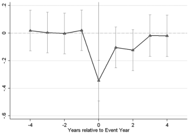

NOTE: figure/graphic rendered as an image from the PDF; its content is not machine-readable text. Caption (if any) follows as the next block.

FIGURE 1. Annual employment changes in the event firm before and after a mass layoff. The figure plots annual changes in log employment in the mass layoff firm, weighted by employment in the pre-event period ( D 1).

to provide a social plan how to reduce the negative economic consequences for those displaced. Such plans often specify compensation packages that become more generous with workers’ age and firm tenure (like early retirement schemes for older workers, for instance).

In light of such regulations, it is not surprising that older workers are strongly overrepresented among displaced workers (panel B of Table 1). The table further reveals that workers who get displaced in a mass layoff are slightly less educated than workers who remain with the event plant. Prior to the mass layoff, displaced workers also earn lower wages and exhibit a lower worker fixed effect than their coworkers in the mass layoff firm.

Figure 1 displays the timing of employment changes (in logs) in the event plant four years before and after the mass layoff event. The figure shows no employment decline in the event firm prior to the actual mass layoff (which occurs between 1 and 0).<sup>21</sup> Employment reductions are, however, substantial in the mass layoff year: a mass layoff destroys on average 1,702 jobs, corresponding to a decline in firm size of 39% (0.33 log-points) and a decline in total employment in the district of 1.9% (see also panel A of Table 1). Thereafter, annual employment declines are smaller and no longer statistically significant.

What types of shocks trigger such large reductions in firm size? Panel A of Table 2 shows that during mass layoff years total employment in the average district

21. We do not find an employment decline before the event–in contrast to some earlier studies (Eliason and Storrie 2006; Pfann and Hamermesh 2008; Schwerdt 2011). We think there are three reasons for the different results. First, we include all layoffs that occur up to a *year* before the layoff (whereas many displacement studies analyze quarterly data). Second, we study mass layoffs and not plant closures; and third, our definition of a mass layoff event rules out equally large shocks in preceding years.

Page 16

442 Journal of the European Economic Association

TABLE 2. Mass layoff versus control districts.

[output not shown]

NOTE: table converted from PDF layout to HTML text; cell boundaries are reconstructed. See PDF if exact alignment matters.

Notes: Columns (1)–(3) compare mass layoff districts, all West German districts and matched control districts in terms of overall employment growth and employment growth in the event industry in the mass layoff year, from D 1 to D 0 (panel A), in terms of characteristics we did not explicitly match on, such as employment and wage growth (panel B), and in terms of characteristics we did explicitly match on (panel C). Columns (4 and 5) report differences between event districts and all West German districts; and columns (6) and (7) report differences between the event and control districts. In panels B and C, all level variables are measured in the pre-event period ( D 1) whereas growth variables are measured from D 6 to D 1. All observations except employment and the share of urban areas are weighted by district employment in the pre-event period ( D 1). Standard errors are clustered at the district level. Significant at 10%; significant at 5%; significant at 1%.

Page 17

Gathmann, Helm, and Sch¨onberg Spillover Effects of Mass Layoffs 443

in West Germany declines by about 1.7% and employment in the (broad) industries experiencing mass layoffs by about 7.4%. The employment declines in the mass layoff regions are very similar: overall regional employment (excluding the event firm) declines by about 1.8% and employment in the same broad industry as the mass layoff firm declines by about 7.1%. Thus, mass layoffs predominantly occur in recessions and in declining industries. Yet, these employment reductions are much smaller in magnitude than the employment decline of 39% suffered by the mass layoff firm. This pattern suggests that the shocks triggering the mass layoffs affect other firms in the same industry to some extent, but hit the mass layoff firms particularly hard. Anecdotal evidence from newspaper articles indicate that mismanagement, cost disadvantages, or offshoring of jobs abroad are the main reasons for the large employment declines.

#### **4. Empirical Strategy**

Our empirical strategy combines matching with an event study approach to flexibly trace employment and wages in regions hit by a mass layoff relative to suitable control regions. We first describe our matching procedure and then explain our baseline estimation regression.

#### *4.1. Matching Treatment and Control Regions*

The key econometric challenge in analyzing the consequences of mass layoffs is that regions experiencing a mass layoff may systematically differ from unaffected regions. Table 2 shows that mass layoff districts are bigger and more urbanized than the average district in West Germany. They further differ in their industry structure: the investment good industry is particularly over-represented in event districts, whereas service industries are generally underrepresented. Mass layoff regions may therefore evolve differently from other regions simply because of (correlated) industry-specific shocks which lower employment not only in the mass layoff firm, but also in other firms operating in the same (or a related) industry.

To identify proper counterfactuals for the mass layoff region, we match to each mass layoff region a control region that, in the four years prior to the mass layoff, was similar in terms of its industry structure (17 broad industries), demographic structure (age groups 16–25, 26–50, and 51–65) and skill structure (low-, medium-, and high-skilled). We do not match on outcome variables, most notably local wages and employment.

In order to find a match for the mass layoff region, we employ a Mahalanobis matching algorithm that minimizes the standardized Euclidean distance of all matching variables between treatment and control regions. Specifically, we normalize the squared distances between treatment and control regions by the variance of the respective variable in the possible control regions and choose the region as control that has the

Page 18

444 Journal of the European Economic Association

smallest sum of normalized squared distances.<sup>22</sup> For this matching procedure to work well, the number of covariates must not be too large (see Stuart and Rubin 2008, Chap. 11). We therefore match on the broad industry structure, which distinguishes 17 industries, and not on a finer industry structure.<sup>23</sup> The particular matching procedure has little impact on our findings. In particular, our results are robust to matching on the 16 broad industries outside the event industry as well as on the 2-digit industry structure within the broad event industry (see specification “matchvar” in Figure A.1 and column (6) in Tables A.1 and A.2 in the Online Appendix). Our results are also largely unchanged when implementing a synthetic control method that, following Abadie and Gardeazabal (2003), constructs for each mass layoff district a synthetic control district as a weighted average of potential control districts (see specification “synthcontrol” in Figure A.1 and column (7) in Tables A.1 and A.2 and Appendix B.1 in the Online Appendix for details).

To rule out other confounding factors, we impose a number of additional restrictions. First, we exclude control districts from the same spatial planning unit to avoid any spillover effects of the mass layoff on the control group.<sup>24</sup> Second, we impose the same set of restrictions on the control regions as on the treatment regions (see conditions (a)–(c) in Section 3.2). Further, we keep control districts only if district employment does not deviate more than 15% from employment in the treatment district in the year prior to the layoff. Finally, we drop matches with the highest distance in the matching variables using a 5% trimming margin.

#### *4.2. Baseline Estimation Regression*

Based on the sample of paired treatment and control regions, we then compare labor market outcomes in the treatment regions to those in the control regions in the periods before and after a mass layoff. In particular, we start with estimating the following

22. The distance equation for all treatment regions *i* and control regions *j* is given by distanceij D <sup>P</sup>

n

P

<sup>.x</sup>in <sup>x</sup>jn<sup>/</sup><sup>2</sup><sup>=s</sup><sup>2</sup>

nj <sup>, where</sup>*<sup>s</sup>nj* <sup>is the standard deviation of variable</sup>*<sup>n</sup>*<sup>in the control</sup> regions *j* and the are indicators for each of the four years prior to the layoff. See, for example, Stuart and Rubin (2008, Chap. 11) for details.

23. An alternative procedure to find suitable control regions would be propensity score matching. Propensity score matching works well if the number of covariates is large and might therefore allow us to match on a finer industry structure. Yet, the approach would require predicting the probability of a mass layoff separately for each event year. In our case, there are, however, too few mass layoffs per calendar year to reliably estimate the propensity score.

24. The 326 districts in West Germany are combined into 78 spatial planning units.

Page 19

Gathmann, Helm, and Sch¨onberg Spillover Effects of Mass Layoffs 445

model at the region level:

2 X

D4

ˇ*Event*

r;t <sup>C</sup>

4 X

D0

*Event*

r;t <sup>are indicator</sup> variables equal to 1 for the event region in period , and 0 otherwise. Note that *t* and differ in our case because mass layoffs occur in any year between 1981 and 2004.

Equation (8) controls for time-invariant differences across regions through region fixed effects (˛*r*) and for aggregate shocks through year fixed effects (ı*t*). Including region and year fixed effects has little impact and primarily improves the precision of our estimates. The event fixed effects are measured relative to the period of the mass layoff. Controlling for both calendar year fixed effects ı*t* and event period fixed effects ensures that we compare outcomes in treatment and control regions in the same calendar year and in the same period relative to the mass layoff. We cluster standard errors by region, thus allowing for an arbitrary correlation of error terms within regions over time. We further estimate variants of equation (8) at the regionindustry level, allowing us to account for industry-specific shocks through the inclusion of industry-specific year fixed effects at the 2- or 3-digit level (as in equation (9)).

Our key identifying assumption is that outcomes in the control regions form a valid counterfactual for outcomes in the treatment regions in the years following the layoff. Since we do not match control regions based on any outcome variables, a comparison between the treatment and control regions in the years prior to the mass layoff allows us to assess the plausibility of this assumption. If the identification assumption is valid, treatment and control regions should experience similar trends in *Yrt* prior to the mass layoff. We show in Section 5.2 that the ˇ coefficients in equation (8) are indeed close to zero and statistically insignificant.

The parameters of interest in equation (8) are 0 to 4, which measure the percentage change in the outcome of interest (e.g., local employment or wages) in the treatment region between years after and one year before the mass layoff relative to the control region. These parameters measure how the firm-specific component of the productivity shock that caused the event firm to shed labor affects the local economy. The aggregate component of the productivity shock, in contrast, affect mass layoff and control regions in the same way and is thus differenced out. Similarly, any industryspecific component is differenced out when we estimate variants of equation (8) at the region-industry level.

Several pieces of evidence suggest that the coefficients 0 to 4 indeed measure the spillover effects of mass layoffs to the local economy, as opposed to industryspecific or local shocks impacting the event and control districts in different ways. First, our matching procedure ensures that treatment and control regions are balanced

Page 20

446 Journal of the European Economic Association

Second, our results show that employment declines in firms other than the event firm start to decline only one year after the mass layoff took place. Moreover, the employment reductions after a mass layoff are highly persistent, and concentrated in firms that operate in the same broad industry and are therefore economically close to the mass layoff firm. These patterns are expected if mass layoffs in one firm cause additional employment losses in other nearby firms because of agglomeration forces (including losses due to input–output linkages) that reinforce each other and accumulate over time. They are, however, only consistent with a confounding local shock if this shock takes a very specific form: it must be specific to a particular industry in the local economy, it must hit the event firm earlier than other firms in that industry, and it must be highly persistent over time.

Third, placebo tests provide further evidence that our baseline matching procedure works well in eliminating possible differences in employment (or wage) dynamics between event and control regions. Using the original event years, we pick a random district in West Germany (not experiencing a mass layoff in the event year) and define it as a placebo event. Based on the same procedure as in the baseline, we then match a suitable control district to the placebo district. If placebo or control region were hit by industry-specific shocks that are not balanced through the matching procedure, we would expect either positive or negative coefficients. However, Table A.3 shows that local economic activity evolves very similarly in the placebo and the control regions both before and after the placebo event.

#### **5. Empirical Results**

#### *5.1. Direct Effects of Mass Layoffs on Displaced Workers*

We start out with examining the direct effects of a mass layoff on workers who got displaced in the layoff event. These direct effects are not only interesting per se but also help us interpret the spillover effects on other plants and workers in the region. If most

Page 21

Gathmann, Helm, and Sch¨onberg Spillover Effects of Mass Layoffs 447

TABLE 3. Effects of mass layoffs on locallabor markets.

Employment Wages Unemployment

Total Effect (incl. event firm) Spillover Effect (excluding event firm) Total Effect Total Effect

Baseline Baseline 2-Digit ind. Year fixed effects 3-Digit ind. Year fixed effects Baseline Baseline

(1) (2) (3) (4) (5) (6)

Event Region ( D 4) 0.002 0.009 0.002 0.007 0.001 0.002 (0.005) (0.007) (0.007) (0.008) (0.002) (0.001)

Event Region ( D 3) 0.001 0.009 0.003 0.002 0.001 0.001 (0.004) (0.006) (0.006) (0.006) (0.002) (0.001)

Event Region ( D 2) 0.000 0.006 0.000 0.000 0.000 0.000 (0.002) (0.005) (0.005) (0.005) (0.001) (0.001)

Event Region (event year) 0.014 0.006 0.005

(0.004) (0.002) (0.001)

Event Region ( D C1) 0.024 0.007 0.009 0.009 0.005 0.007

(0.005) (0.003) (0.003) (0.003) (0.003) (0.002)

Event Region ( D C2) 0.028 0.008 0.012 0.010 0.002 0.006

(0.006) (0.005) (0.004) (0.006) (0.003) (0.002)

Event Region ( D C3) 0.030 0.009 0.014 0.014 0.002 0.005

(0.007) (0.006) (0.005) (0.008) (0.004) (0.002)

Event Region ( D C4) 0.037 0.014 0.022 0.020 0.001 0.006

(0.008) (0.007) (0.007) (0.010) (0.004) (0.002)

Event Period Fixed Effects Yes Yes Yes Yes Yes Yes

Year Fixed Effects Yes Yes – Yes Yes

Region Fixed Effects Yes Yes – – Yes Yes

Region Industry Fixed Effects – – Yes Yes – –

Industry Year Fixed Effects – – 2-digit 3-digit – –

Number of Events 62 62 62 62 62 62

Notes: The table reports estimates of the effects of mass layoffs on employment, unemployment and wages in event districts based on equation (8). Columns (1), (5), and (6)

show results for the district as a whole, whereas columns (2)–(4) focus on spillover effects excluding employment in the event firm. Columns (1), (2), (5), and (6) are estimated

at the district level, column (3) is estimated at the 2-digit industry–district level and conditions on 2-digit industry-year fixed effects (60 industries) and column (4) is estimated

at the 3-digit industry–district level and conditions on 3-digit industry-year fixed effects (222 industries). The dependent variables are log employment at the respective level of

estimation in columns (1)–(4), the average log daily wage (in EUR at 1995 prices) in the district in column (5) and the district unemployment rate in column (6). Regressions are

weighted by district employment in the pre-event period ( D 1). In columns (1), (5), and (6), the base period is D 1; in the remaining columns it is D 0, the event year.

Standard errors are clustered at the district level. Significant at 10%; significant at 5%; significant at 1%.

Page 22

448 Journal of the European Economic Association

displaced workers move away or withdraw from the labor market, for instance, local labor supply and therefore local wages should not be affected much in the absence of agglomeration forces.

Figure 2 shows that displaced workers suffer severe negative consequences in the labor market. Compared to workers in the matched control districts, employment rates of displaced workers decline by almost 60 percentage points in the year of the layoff.<sup>25</sup> Though their employment rates recover somewhat over time, four years after the mass layoff displaced workers are still almost 40 percentage points less likely to be employed than workers in the control regions (panel (a)). Mirroring the large employment decline, displaced workers are also much more likely to be unemployed following displacement (panel (b)). Over time, unemployment declines sharply from 30% just after displacement to about 3% four years later. This pattern is not surprising as unemployment benefits expire after a period between 6 and 32 months depending on worker’s age and length of employment prior to the layoff.<sup>26</sup>

In contrast, the share of displaced workers who either work outside the social security system (e.g., in the military, as a civil servant or in self-employment) or left the labor force altogether remains high ranging from 27% initially to 33% four years after the layoff (panel (c)). As many displaced workers in our sample are over 50 and therefore entitled to generous severance payments and early retirement packages, most of the movements out of the social security system are likely to be permanent withdrawals from the labor market. In what follows, we refer to all workers not covered by the social security system as nonemployed. Furthermore, displaced workers are about 11 percentage points more likely to be employed in a different district four years after displacement (panel (d)) than workers in the matched control districts.

Overall, Figure 2 illustrates that displaced workers suffer large and persistent employment and wage losses following the layoff. In terms of magnitude, these losses are larger than most estimates documented in the existing literature, probably because of the particular way we construct our sample. Layoffs in our sample are unusually

25. Note that displaced workers in the event region and all workers in the control regions are employed before the mass layoff, in D 1.

26. To receive unemployment benefits, a person has to be employed and paid UI contributions for at least 12 months over the preceding three years. Throughout most of our sample period, unemployment benefits were means tested and 60% (67%) of the last net wage for a recipient without (with) children.

Page 23

Gathmann, Helm, and Sch¨onberg Spillover Effects of Mass Layoffs 449

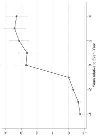

NOTE: figure/graphic rendered as an image from the PDF; its content is not machine-readable text. Caption (if any) follows as the next block.

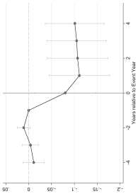

NOTE: figure/graphic rendered as an image from the PDF; its content is not machine-readable text. Caption (if any) follows as the next block.

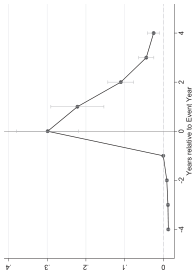

NOTE: figure/graphic rendered as an image from the PDF; its content is not machine-readable text. Caption (if any) follows as the next block.

(a) Employment (b) Unemployment

(d) Employment in Other Regions (e) Wages

(c) Out of Labor Force & Work Outside Social Sec. System

FIGURE 2. Effects of mass layoffs on displaced workers. The figure reports estimates of the effects of mass layoffs on displaced workers based on equation (8).

The control group consists of all workers employed in the pre-event period ( D 1) in control districts. Observations in panels (a)–(d) are measured at the

district level (1116 observations). Panel (a) plots the effects of mass layoffs on displaced workers’ employment probabilities. Panel (b) plots the effects on

displaced workers’ unemployment probabilities. Panel (c) plots the effects on being out of the labor force or working outside the social security system (in

the military, as a civil servant or as self-employed). Panel (d) plots the effects on displaced workers’ probability to work in another region. Regressions are

weighted by the number of displaced individuals in event districts and by district employment in the pre-event period in control districts. Observations in panel

(e) are at the individual level and restricted to full-time workers (36,753,461 observations). The dependent variable is the log daily wage (base year 1995). We

include individual fixed effects in the regression to avoid compositional changes and exclude displaced workers who return to the mass layoff firm two years

after the mass layoff (to account for recalls). Standard errors are clustered at the district level. Significant at10%; significant at 5%; significant at 1%.

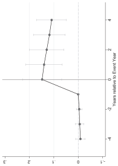

NOTE: figure/graphic rendered as an image from the PDF; its content is not machine-readable text. Caption (if any) follows as the next block.

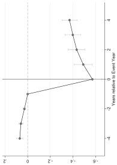

NOTE: figure/graphic rendered as an image from the PDF; its content is not machine-readable text. Caption (if any) follows as the next block.

Page 24

450 Journal of the European Economic Association

large in size, occur in high-wage firms and disproportionally displace older workers.<sup>27</sup>

Displaced workers may therefore find it especially difficult to find comparable jobs in the local economy that are as well-paid as the job lost.

#### *5.2. Spillover Effects of Mass Layoffs on the Region*

*5.2.1. Baseline Results.* Do mass layoffs have negative effects on the local economy beyond those for the displaced workers? Figure 3 suggests indeed that there are substantial spillover effects of mass layoffs. In panel (a), we plot employment growth in treatment and control regions before and after the layoff, where we normalize employment growth to 0 in the year prior to the layoff in both regions. In the four years prior to the layoff, local employment grows by about 3% in both regions. In the year of the layoff, local employment drops in both treatment and control regions as most of our events take place in recessions. The drop is, however, much more pronounced in the event region. In the years following the layoff, local employment remains roughly constant in control regions, but continues to decline in event regions.

To investigate these effects more systematically, column (1) of Table 3 shows the time-varying effects of a mass layoff on local employment based on equation (8), and panel (b) of Figure 3 plots the coefficients (gray line). Estimates for the years prior to the layoff event (corresponding to ˇ in equation (8)) are small in magnitude and not statistically significant from zero. The picture changes dramatically after the layoff: Following an immediate decline of 1.4%, employment losses accumulate over time. Four years after the layoff, employment in the event region is 3.7% lower than in the control region. Hence, the employment loss in the region is almost double the initial mass layoff that destroyed 1.9% of local jobs (see panel A of Table 1).

How much of this employment decline is driven by the event firm, and how much by other firms in the local economy?<sup>28</sup> In column (2) of Table 3, we rerun the same specification for local employment as before but exclude event firm employment. The coefficients are plotted in panel (b) of Figure 3 (dark line).<sup>29</sup> The estimates reveal that other firms in the same district suffer employment losses as well: employment drops

27. The displacement literature (see, e.g., Bender et al. 2002; Burda and Mertens 2011; Schmieder et al. 2009 for Germany; Jacobson et al. 1993; Wachter et al. 2009; Wachter et al. 2009 for the United States) typically studies smaller firms where mass layoffs or plant closures displace 30 or 50 workers. Furthermore, the existing literature focuses on 25–50 year-old men, whereas we include men and women of all age groups in our analysis.

28. Employment in other firms is calculated by excluding all employees in plants that are connected to the event firm through breakups, spin-offs, or mergers. A plant is a breakup or spin-off if at least 200 individuals leaving the event firm move to that plant and make up at least 50% of the worker inflow in that plant. Similarly, a merger is defined as a plant that sends at least 200 individuals to the event firm and these make up at least 50% of the worker outflow in that plant.

29. To allow for spillover effects on other firms in the local economy to materialize, we use D 0 as the base year when excluding employment in the event firm in column (2). In contrast, when analyzing the effects of a mass layoff on overall local employment in column (1), we use D 1 as the base year.

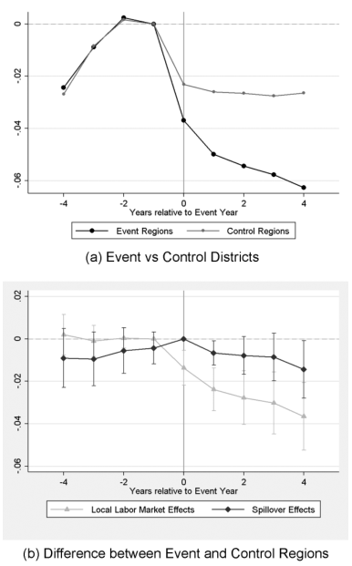

These baseline results in Table 3, columns (1) and (2), are based on a sample of treatment and control districts that resemble each other in terms of their broad industry

structure (see Table 2). Therefore, national shocks to broad industries cannot explain the divergent employment trends in the mass layoff regions relative to control regions. Broad industries might, however, be too coarse to balance all industry-specific shocks between event and matched control regions. To address this concern, we re-estimate equation (8) at the 2- and 3-digit industry-region level, and condition on 2- or 3- digit industry-year fixed effects (columns (3) and (4)).<sup>30</sup> These specifications show if anything a slightly more pronounced employment decline in other firms located in the event region of 2.5% and 2%, respectively, further suggesting that the employment reduction in the mass layoff regions relative to control regions is indeed triggered by the mass layoff event, and not by aggregate shocks to specific industries.

So far, we focused on the impact of mass layoffs on local employment. In columns (5) and (6) of Table 3, we investigate how mass layoffs affect local wages and local unemployment. Although employment declines are substantial, we find little evidence for a persistent downward pressure on wages in event regions relative to control regions (see column (5)). The absence of persistent wage effects indicates either that local labor supply is very elastic (i.e., in equations (5) and (6) is close to zero), or that local wages exhibit downward rigidity. In both cases, the full adjustment to the negative demand shock (from the initial layoff and any spillover effects on other plants) occurs through a long-run reduction in local employment.

Table 3 further reveals that mass layoffs increase the local unemployment rate by between 0.5 and 0.7 percentage points one to four years after the mass layoff (see column (6)). Relative to the overall employment decline of 3.7%, however, this increase in local unemployment is small. These numbers suggest that local employment mainly adjusts through other channels, such as geographic mobility or movements into and out of nonemployment. We further investigate these channels in Section 5.3.

*5.2.2. Results by Industry.*

*Same versus Different Industry.* Our evidence so far points to substantial employment losses not only in the local economy as a whole, but also in firms other than the event firm. If agglomeration effects are responsible for the local employment decline, then employment reductions should be stronger in firms that are economically closer to the event firm. We proxy closeness through industry affiliation, and test whether firms in the same broad industry as the event firm experience larger employment declines than other firms in the tradable sector.

To do so, we estimate regressions at the region-industry level (as in columns (3) and (4) of Table 3) and allow the spillover effect of a mass layoff to differ for firms in

the same broad industry as the event firm and those in other industries:

where the subscript *i* now represents 2-digit industries. As before, the subscripts *r*, *t*, and denote region, calendar time and the period relative to the event, respectively. *Yirt* measures (log) employment in industry *i* and region *r* at time *t* excluding the event firm. *Event*<sup>same</sup><sup>;</sup>

i;r;t ) are indicator variables equal to 1 if an industry *i* belongs to the same (another) broad industry in event region *r* in period , and 0 otherwise. The specification now includes region-specific industry fixed effects (*air*) and industry-specific calendar year fixed effects (ı*it*) to allow for differential industryspecific trends over time. As before, we include event period fixed effects () to ensure that we compare outcomes in the same calendar year and in the same period relative to the mass layoff.

Columns (1) and (2) of Table 4 highlight that employment losses are particularly large in firms operating in the same broad industry as the event firm. Here, the employment decline grows to 5% four years after the layoff, compared to 2.4% in firms in other broad industries within the tradable sector. Furthermore, employment losses of firms in the same broad industry but outside the event firm’s 2-digit industry are similar in magnitude to the employment losses in the same broad industry overall (compare columns (1) and (3)). This finding speaks against the idea that employment reductions in firms other than the mass layoff firm merely reflect an industry-specific shock that hits all firms in the same 2-digit industry in the similar way. That result further rules out the possibility that the employment decline in the mass layoff regions (compared to the control regions) merely reflects employment gains of firms in the control regions competing with the mass layoff firm for market shares. The estimates in column (4) further highlight that our findings are robust to estimating equation (9) at the 3-digit (rather than 2-digit) industry-region level and controlling for detailed 3-digit industry-year fixed effects.

*Tradable versus Nontradable Sector.* The evidence so far points to sizable agglomeration effects of the mass layoff on other firms in the tradable sector and especially, in the same broad industry as the event firm. Yet, does mass job destruction also trigger additional job losses in the nontradable service sector, as we would expect in the presence of local multipliers? And are employment losses in the nontradable sector more or less prevalent than employment losses in the tradable sector?

To address these questions, we re-estimate equation (9), but now allow the effects of mass layoffs to differ between firms in the tradable and the nontradable sector. Column (5) and (6) of Table 4 show that local employment (excluding event plant employment) declines in both the tradable and nontradable sector after a mass layoff took place. But the decline is much more pronounced in the tradable sector: Four years after the layoff, employment in the tradable sector declined by 3.5% compared

TABLE 4. Spillover effects in local employment from mass layoffs by industries.

Tradable Sector only Tradable versus Nontradable Sector

Same Broad Different Broad Same Broad Industry Same Broad Industry Tradable Nontradable Tradable Sector

Industry Industry (different 2-digit ind.) (3-digit level) Sector Sector incl. Event Firm

(1) (2) (3) (4) (5) (6) (7)

Event Region ( D 4) 0.005 0.007 0.003 0.035 0.006 0.000 0.003 (0.013) (0.010) (0.016) (0.023) (0.009) (0.007) (0.007)

Event Region ( D 3) 0.007 0.007 0.003 0.001 0.007 0.001 0.003

(0.012) (0.008) (0.014) (0.012) (0.008) (0.006) (0.005)

Event Region ( D 2) 0.004 0.006 0.001 0.004 0.005 0.003 0.000 (0.010) (0.007) (0.011) (0.010) (0.007) (0.005) (0.003)

Event Region ( D 1) 0.004 0.002 0.003 0.000 0.003 0.003 (0.008) (0.006) (0.009) (0.009) (0.006) (0.003)

Event Region (event year) 0.024

(0.009)

Event Region ( D C1) 0.018 0.013 0.020 0.018 0.015 0.005 0.045

(0.008) (0.006) (0.009) (0.009) (0.006) (0.003) (0.009)

Event Region ( D C2) 0.017 0.017 0.022 0.020 0.017 0.008 0.049

(0.010) (0.008) (0.011) (0.013) (0.007) (0.004) (0.010)

Event Region ( D C3) 0.025 0.016 0.033 0.037 0.020 0.010 0.061

(0.013) (0.009) (0.016) (0.017) (0.008) (0.006) (0.013)

Event Region ( D C4) 0.050 0.024 0.060 0.063 0.035 0.014 0.074

(0.017) (0.012) (0.022) (0.021) (0.011) (0.007) (0.014)

Event Period Fixed Effects Yes Yes Yes Yes Yes Yes Yes

Industry Year Fixed Effects 2-digit 2-digit 2-digit 3-digit 2-digit 2-digit 2-digit Industry Region Fixed Effects Yes Yes Yes Yes Yes Yes Yes

Notes: The table reports estimates of the effects of mass layoffs on log employment in different industries. Industries are defined at the 2-digit level (60 industries) in all columns

except column (4) where industry refers to the 3-digit level (222 industries). In columns (1)–(4), the sample is restricted to firms in the tradable sector. In columns (1), (2), and (4),

we display spillover effects in employment separately for firms in the same and different broad industry as the mass layoff firm. In column (3), we show spillover effects in the same

broad sector, but outside the 2-digit industry as the mass layoff firm. In columns (5) and (6), we report spillover effects in employment separately for the tradable and nontradable

sector (excluding the mass layoff firm). In column (7), we display employment effects from mass layoffs in the tradable sector including the mass layoff firm. Regressions are

estimated at the industry district level and are weighted by industry–district employment in the pre-event period ( D 1). Estimates are based on variants of equation (9) and

control for district x industry fixed effects, event period fixed effects and industry year fixed effects. Standard errors are clustered at the district level. Significant at 10%;

significant at 5%; significant at 1%.

to only 1.4% in the nontradable sector.<sup>31</sup> These findings suggest that although both agglomeration and local multiplier effects contribute to the local employment decline, agglomeration effects play a more important role.

We would also like to stress that in all specifications of Table 4, employment in firms other than the mass layoff firm drops only one year after the actual mass layoff (i.e., from D 0 to D C1), as we would expect if the employment losses were caused by agglomeration or local multiplier effects. Overall, the evidence presented in Table 4 helps to rule out concerns that the employment decline in the mass layoff region merely reflects a region-specific demand shock affecting all firms in the local economy simultaneously in the same way. The findings in Table 4 are also difficult to reconcile with industry-specific shocks that simultaneously hit all firms in the industry, but differently affect the event and control regions because of differences in their industry structure. Instead, Table 4 supports the hypothesis that the overall decline in local employment following the mass layoff is predominantly caused by agglomeration forces.

*Input–Output Linkages.* We further investigate whether employment declines more in firms that are connected to the event firm through input–output linkages (Table 5). To do so, we re-estimate a variant of equation (9) but add an interaction effect between the event dummies *Event<sup>trad</sup>*<sup>;</sup>

r;s;t <sup>and a measure of input–output linkages to the specification.</sup> As before, we restrict the sample to firms in the tradable sector. We define input–output linkages in two ways: by the share of all tradable *output* that is *sold* by the industry under observation to the event industry (columns (1) and (3)) and by the share of all tradable *inputsbought* by the industry under observation from the event industry (columns (2) and (4)). We compute these linkages from two sources: the first source are German input–output tables in 1995, which are available at the 2-digit industry level. The 2-digit industry level might be too coarse to pick up spillover effects due to input– output linkages. We therefore use as a second source US input–output tables, which are available at the 3-digit industry level and published by the Bureau of Economic Analysis (BEA). Each measure is standardized to have mean 0 and standard deviation of 1. The correlation between the German and the US upstream measure is 0.37 and the correlation between the two downstream measures is 0.46.

The reported coefficients in Table 5 correspond to the interaction terms between the event dummies and the two measures of input–output linkages. They measure how a change in input–output linkages (by one standard deviation) affects the employment loss in the industry under consideration in the mass layoff region. Results on German input–output tables in columns (1) and (2) of Table 5 suggest no significant relationship between the size of the local employment loss in an industry and the degree of input– output linkages with the event industry. Using the more detailed US input–output

31. The difference is statistically significant just below the 10% level. Also, the tradable sector share on overall local employment is 46%. This implies that four years after the layoff the decline in tradable sector employment contributed more than twice as much to the decline in overall local employment than the nontradable sector (0.035 0.46 D 1.61% vs. 0.014 0.54 D 0.76%).

TABLE 5. Spillover effects and input–output linkages.

[output not shown]

Notes: The table investigates whether spillover effects in employment from mass layoffs differ by the degree of input–output linkages with the event industry. The degree of input–output linkages in columns (1) and (2) is measured at the 2-digit industry level using German input–output tables. In columns (3) and (4) input–output linkages are measured at the 3-digit industry level using the US input–output tables to proxy for the German input–output relations. Estimation is at the industry district level and the dependent variable is log industry employment (excluding the event firm). Regressions are weighted by industry–district employment in the preevent period ( D 1). We distinguish between two measures of input–output linkages: the share of all output provided to tradable good producers that is sold to the event industry (columns (1) and (3)) and the share of all inputs used from tradable good producers that is bought from the event industry (column (2) and (4)). The reported coefficients are for the interaction terms between the event dummies and the respective input–output linkage measure. They measure how a change in input–output linkages (by one standard deviation) affects the employment loss in the industry under consideration in the mass layoff region. Standard errors are clustered at the district level. Significant at 10%.

tables in columns (3) and (4) of Table 5 confirms that the employment spillover effects that we uncover are not driven by input–output linkages. These findings indicate that input–output linkages play only a minor role for the observed spillover effects in the tradable sector following a mass layoff.

*Magnitudes: Local Multiplier and Agglomeration Elasticity.* To put the estimated employment losses in the nontradable and tradable sector into perspective, we now use our estimates to back out a local multiplier and, using the structure of the model, the agglomeration elasticity .

We calculate the local multiplier as follows: the decline in employment in the nontradable sector is 1.4% (see column (6) of Table 4) and the employment share in the nontradable sector is 0.54, implying that overall local employment declined by 0.76% (0.014 0.054) because of the contraction in the nontradable sector. Together with the initial job destruction in the mass layoff firm of 1.9% relative to baseline total local employment (see Table 1) this implies a local multiplier of 0.40 (0.0076=0.019): each initial job loss in the tradable sector leads to 0.4 additional job losses in the nontradable sector. This estimate is smaller than those reported in Moretti (2010), but in line with estimates reported in Moretti and Thulin (2013) and Faggio and Overman (2014).

Using the structure of the model, we can further back out the agglomeration elasticity . Starting from equation (7), and assuming that—in line with our evidence in column (5) of Table 3—local wages do not adjust to mass layoffs (i.e., *d* log w*r* D 0), the agglomeration elasticity equals

The agglomeration elasticity depends on the fixed capital share (1 ˛)(1 ) because that parameter determines how firm and local labor demand respond to changes in productivity. The smaller the fixed capital share, the less of a constraining effect the fixed production factor has on the labor demand response. Following Kline and Moretti (2014), a reasonable value for the share of fixed capital in production, (1 ˛)(1 ), is 0.47.<sup>32</sup> From columns (5) and (7) in Table 4, employment losses in the tradable sector with and without the mass layoff firm have accumulated to 7.4% and 3.5% respectively four years after the mass layoff (i.e., d log Lj ¤*event* D 0:035 and *d* log *Lr* D 0.074). Setting *J*=(*J* 1) D 1 for simplicity, our estimate of the agglomeration elasticity is 0.22 ((0.035=0.074) 0.47). Hence, a 1% decline in local employment in the tradable sector leads to a reduction in productivity in that sector by 0.22%. Our estimate is very similar to the estimate of 0.20 reported by Kline and Moretti (2014) who exploit a “big push” infrastructure investment program to calculate the agglomeration elasticity. It is also similar to the elasticities estimated in Helm (2017) and Dix-Carneiro and Kovak

32. Kline and Moretti (2014) assume that the labor demand elasticity, in our model given by (1 (1 ˛))=((1 ˛)(1 )), is equal to 1.5, and that the share of flexible capital in production, in our model given by (1 ˛), is equal to 0.3. It follows that the share of fixed capital is: (1 ˛)(1 ) D 0.47.

(2017) who study the effects of trade liberalization on local labor markets. All three estimates are larger than the elasticity of 0.06 reported in the seminal study of Ciccone and Hall (1996). The difference in the estimated elasticities may be explained by the type of variation used to identify the agglomeration elasticity: whereas we rely on massive job destruction in high-wage firms producing in the tradable sector, Ciccone and Hall (1996) use cross-sectional variation in the regional employment density more broadly.<sup>33</sup>

*5.2.3. Additional Findings.*

*Long-Run Effects of Mass Layoffs.* Are the negative consequences of a mass layoff we document permanent? Or, are these transitory effects that disappear after a few years and have no consequences for the long-run development of the local economy?

To study long-run effects, we re-estimate variants of equation (8) at the 2-digit industry-region level. The specification includes separate coefficients for up to ten years after the mass layoff ( 10) and controls for 2-digit industry-year fixed effects to account for differential changes in the industry structure between event and control regions over the course of a decade. Our sample now consists of 55 events and their respective control regions as we have to drop mass layoffs occurring after 1998.

Panel (a) of Figure 4 shows that the employment effects of a mass layoff are highly persistent over time. A decade after the mass layoff event, the event region has lost 6.5% of its employment or nearly 5,200 jobs compared to the control region—considerably more than through the initial mass layoff. Spillover effects on employment in other firms in the region are with 4% large and persistent as well. Panel (b) of Figure 4 shows separate estimates for the tradable and nontradable sector: the tradable sector is much more affected than the nontradable sector. Yet, the relative importance of employment losses in the tradable sector does not change much over time accounting for about 70% of the overall employment decline. In line with our findings in Table 4, employment losses ten years after a mass layoff took place are most concentrated in firms that operate in the same broad sector as the event firm.<sup>34</sup>

*Spillover Effects to Neighboring Districts.* Spillover effects of mass layoffs may spread beyond district boundaries. To check for this possibility, we re-estimate variants of equation (8) and (9) at the 2-digit industry-region level, with all neighboring districts sharing a boundary with the event and control districts as the regional unit of our analysis. To account for the possibility that neighboring districts of event and control districts differ in their industry structure, we control for 2-digit industryyear fixed effects in our regressions. Table 6 shows that there is little evidence for spillover effects to neighboring districts: neither total regional employment (column

33. In a recent meta-analysis of agglomeration elasticities, Melo et al. (2009) report estimates ranging from 0.07 to 0.13 but also note that estimates vary a lot depending on the industry and country analyzed.

34. In fact these effects continue to grow even 14 years after the mass layoff took place with no indication for reversion.

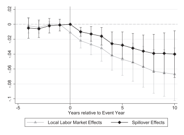

(a) Regional and Spillover Effects in the Long-Run

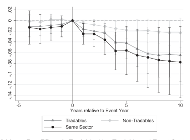

(b) Long-Run Effects in Tradable, Non-Tradable and Event Sector

FIGURE 4. Long-run effects of mass layoffs on local employment. The figure plots, based on a variant of equation (9), the long-run effects of mass layoffs. Panel (a) plots the long-run effects of mass layoffs on overall local employment (light gray line) and on local employment excluding the event firm (black line). Panel (b) plots, the effects on employment in the tradable sector (medium gray line), the nontradable sector (light gray line) and in the same broad industry as the mass layoff firm (black line). Regressions are estimated at the 2-digit industry district level and control for district industry fixed effects, event period fixed effects and 2-digit industry year fixed effects, and trace out the effects of mass layoffs on local employment up to 10 years (as opposed to 4 years in the baseline specification) after the event. Since we have to drop events occurring after 1998, the sample reduces to 55 (as opposed to 62) events and their control districts.

(1)), nor employment in the tradable or nontradable sector (columns (2) and (3)), nor employment in the same broad industry (column (4)) are affected by a mass layoff in a neighboring district. The negative spillover effects of mass layoffs therefore appear to be spatially concentrated in firms located in the same district as the mass layoff firm.

TABLE 6. Mass layoffs and employment losses in neighboring districts.

[output not shown]

Notes: The table reports estimates of the spillover effects in employment from mass layoffs in districts sharing a border with the mass layoff district (neighboring districts). We first report estimates of the spillover effects on employment in the neighboring districts as a whole (column (1)). We then allow the spillover effects to differ between the tradable and nontradable sector (columns (2) and (3)). In column (4), we display spillover effects in firms in neighboring districts that operate in the same broad sector as the mass layoff firm. There are 167 neighboring districts in our sample. Regressions are estimated at the (2-digit) industry district level and are weighted by industry–district employment in the pre-event period ( D 1). Estimates are based on variants of equation (9) and control for district industry fixed effects, event period fixed effects and industry year fixed effects. Standard errors are clustered at the district level.

#### *5.3. Regions versus Workers*

Our results indicate a strong and persistent decline in local employment of 3.7% four years and 6.5% ten years after the mass layoff. Yet, the job losses at the *local* level do not necessarily imply that *workers* who were employed in the local economy at the time of the mass layoff face worse employment prospects. Job losses in the local economy may mainly reflect the reallocation of workers from declining to more prospering regions, as workers employed in the mass layoff region find jobs in other local economies, or workers with jobs in other regions refrain from moving into the mass layoff region.

To investigate the various margins through which local employment adjusts, we shift the analysis from the regional to the individual level. In Table 7, we report estimates from our baseline regression in equation (8), but now follow the labor market careers of workers (including those displaced) who at the time of the mass layoff were employed in the mass layoff regions, even if they leave that region later on.<sup>35</sup> We restrict attention to attached workers who were employed in the region in the three years prior to the layoff.<sup>36</sup> The table shows that attached workers in the event region are less likely to be employed after the mass layoff than workers in the control region (column (1)). However, the decline in employment for the individual worker is substantially smaller than the decline in local employment (compare 0.8 percentage points to 3.7% four years after the layoff).<sup>37</sup> Hence, outflows of employed workers into un- or nonemployment account for only 20% (0.008=0.037) of the overall local employment decline.

Columns (2) and (3) of Table 7 highlight that the discrepancy between the decline in employment at the local and individual level is partially explained by workers moving away from the region and finding employment in other regions. Four years after the mass layoff, workers in the mass layoff district are 1.8 percentage points less likely to remain employed in the same district, and 1 percentage point more likely to be employed in a different district, than workers in the control group.

Although worker outflows from mass layoff regions to other regions are important, they cannot alone account for the much smaller employment response at the individual compared to the local level. The remaining difference can be explained by a reduction in inflows of workers into the event region, either from employment in other regions or from un- or nonemployment. To investigate the reduction of inflows into the local labor market, we estimate the baseline regression (see equation (8)), now using cumulative inflows, normalized by regional employment just prior to the mass layoff (in D 1), as the dependent variable. The results in columns (4)–(6) of Table 7 show that worker inflows into the region indeed decline after a mass layoff: Four years after the mass layoff, total worker inflows are 2.3 percentage points lower in event than in control regions (column (4)). More than half of the reduction in total worker inflows stem from workers who were employed in other regions in the previous year (1.3 percentage points, column (5)), whereas reductions in inflows from un- or nonemployment account for the rest (1 percentage point, column (6)). Taken together, worker reallocations across local labor markets, either through higher outflows to other regions (column (3) of Table 7) or through reduced inflows from other regions (column

35. In our data, we do not directly observe where workers reside. But the evidence suggests that about 85% of workers who are no longer employed in the event district after the mass layoff do not find jobs in the same broader commuting zone. Instead, they find employment in districts outside the commuting zone and are thus likely to move away from the region.

36. This restriction has little effect on the estimates after the layoff but reduces pre-event differences of employment in the same district between workers in the event and control regions.

37. It should be noted that the two effects are comparable, as the dependent variable in the worker regression is normalized by local employment in the pre-event period. A reduction of 0.8 percentage points in employment of attached workers hence corresponds to a reduction in local employment of 0.8%.

TABLE 7. Effects of mass layoffs on employment outflows and inflows.

Outflows: Attached Workers Inflows

Employment Employment Employment Total Inflows Inflows from

Same District Different District Other Districts Un-/Nonemployed

(1) (2) (3) (4) (5) (6)

Event Region ( D 4) 0.004 0.001 0.003 0.001 0.007 0.007

(0.002) (0.003) (0.002) (0.005) (0.003) (0.004)

Event Region ( D 3) 0.001 0.001 0.000 0.001 0.003 0.004

(0.002) (0.002) (0.001) (0.003) (0.002) (0.002)

Event Region ( D 2) 0.001 0.001 0.000 0.002 0.001 0.001 (0.001) (0.001) (0.001) (0.002) (0.001) (0.001)

Event Region ( D 1)

Event Region (event year) 0.004 0.008 0.004 0.005 0.002 0.003

(0.003) (0.003) (0.002) (0.005) (0.002) (0.004)

Event Region ( D C1) 0.007 0.014 0.006 0.011 0.006 0.005

(0.002) (0.004) (0.003) (0.005) (0.003) (0.004)

Event Region ( D C2) 0.008 0.015 0.008 0.015 0.008 0.006

(0.003) (0.005) (0.003) (0.006) (0.003) (0.004)

Event Region ( D C3) 0.007 0.015 0.008 0.019 0.011 0.008

(0.003) (0.005) (0.003) (0.007) (0.004) (0.005)

Event Region ( D C4) 0.008 0.018 0.010 0.023 0.013 0.01

(0.003) (0.006) (0.004) (0.009) (0.005) (0.006)

Event Period Fixed Effects Yes Yes Yes Yes Yes Yes

Year Fixed Effects Yes Yes Yes Yes Yes Yes

Region Fixed Effects Yes Yes Yes Yes Yes Yes

Notes: The table analyzes how mass layoffs affect worker flows into and out of the mass layoff region based on estimating variants of equation (8). In columns (1)–(3), we report

effects on the career trajectories of attached workers who were employed in the event or control districts in the three years prior to the event (i.e., from ( D 3) to ( D 1)). The

dependent variables are shares of workers engaged in the activity reported in the top row (employment, employment in the same, and employment in a different district) scaled by

district employment of attached workers in the pre-event period ( D1). Regressions are estimated at the district level and weighted by district employment of attached workers

in the pre-event period. Columns (4)–(6) report effects on inflows into event district employment. The dependent variables are the shares of total inflows (column (4)), inflows

from employment in other districts (column (5)), and inflows from un- or nonemployment (column (6)) scaled by district employment in ( D 1). Regressions are weighted by

overall district employment in the pre-event period ( D 1). Standard errors are clustered at the district level. Significant at 10%; significant at 5%; significant at 1%.

(5) of Table 7) account for a substantial share (over 50%) of the total decline in local employment.

In Table 8, we break down the individual level analysis by age. The results are striking: employment losses of individuals employed in the event region at the time of the mass layoff are heavily concentrated among older individuals (51- to 65-yearolds) who are 3.4 percentage points less likely to be employed four years after the mass layoff. In contrast, young (16- to 25-year-olds) and prime-aged workers (26- to 50-year-olds) experience no decline in employment following the mass layoff. This difference can be explained by the fact that young and prime-aged workers are more likely to seek employment in other local economies (columns (4) and (5)). Older workers, in contrast, do rarely move away to find employment elsewhere (column (6)).

Columns (7)–(9) further show that inflows into employment in the affected region decrease the most for young workers: four years after the layoff, inflows of 16- to 25-year-olds into the mass layoff region are 5.4 percentage points lower compared to the control region. Effects are with 1.9 percentage points weaker for prime-aged workers and basically zero for older workers. These findings suggest that mass layoffs disrupt the flow of young and prime-aged workers into the region and hence the supply of new human capital to the local economy.

Tables A.4 and A.4 further show results by education and gender. The results in Table A.4 suggest that high-skilled workers in mass layoff regions do not face a reduction in their employment prospects as all of the adjustment to the mass layoff comes from a reduction in inflows. Medium- and low-skilled workers in contrast, suffer from employment declines in the region. Yet, even for these groups, the main adjustment occurs through workers moving away and finding jobs in other regions and reduced inflows of workers into the region. Finally, Table A.5 shows that employment prospects of men decline slightly more than those of women, possibly because men are more likely to work in the manufacturing sector than women. The basic adjustment mechanisms are however, quite similar: both men and women experience higher outflows to other regions and reduced inflows into the event region after the mass layoff.

Overall, these findings highlight that even over the relatively short time span considered here, worker reallocations across regions are an important margin of adjustment in Germany. Geographic mobility is a particularly important adjustment channel for workers younger than 50. Workers from this age group who were employed at the time of the mass layoff are nearly fully shielded from the decline in local employment opportunities. As a result, their employment prospects are not much affected by the mass layoff. The picture looks less positive for workers older than 50. These workers are no longer geographically mobile—possibly because of their proximity to retirement age—and in consequence their employment prospects are permanently reduced by the mass layoff.

TABLE 8. Effects of mass layoff on employment outflows and inflows by age groups.

Outflows: Attached Workers Inflows

Employment by Age Group Employment Different District by Age Group Total Inflows by Age Group

Age 16–25 Age 26–50 Age 51–65 Age 16–25 Age 26–50 Age 51–65 Age 16–25 Age 26–50 Age 51–65

(1) (2) (3) (4) (5) (6) (7) (8) (9)

Event Region ( D 4) 0.004 0.003 0.001 0.007 0.003 0.001 0.000 0.002 0.001 (0.004) (0.003) (0.003) (0.004) (0.002) (0.001) (0.009) (0.006) (0.004)

Event Region ( D 3) 0.001 0.001 0.000 0.000 0.000 0.000 0.001 0.001 0.000 (0.003) (0.002) (0.002) (0.001) (0.001) (0.000) (0.006) (0.003) (0.003)

Event Region ( D 2) 0.001 0.001 0.001 0.000 0.000 0.000 0.004 0.002 0.000 (0.002) (0.001) (0.001) (0.001) (0.001) (0.000) (0.003) (0.002) (0.001)

Event Region ( D 1)

Event Region (event year) 0.001 0.002 0.028 0.008 0.005 0.001 0.008 0.005 0.001

(0.004) (0.003) (0.007) (0.004) (0.002) (0.001) (0.010) (0.005) (0.002)

Event Region ( D C1) 0.000 0.000 0.036 0.011 0.007 0.002 0.019 0.011 0.000 (0.004) (0.002) (0.009) (0.005) (0.003) (0.001) (0.009) (0.005) (0.003)

Event Region ( D C2) 0.003 0.001 0.041 0.013 0.009 0.002 0.03 0.013 0.000 (0.004) (0.003) (0.011) (0.006) (0.004) (0.001) (0.011) (0.006) (0.004)

Event Region ( D C3) 0.004 0.001 0.038 0.015 0.011 0.001 0.043 0.016 0.000 (0.004) (0.003) (0.010) (0.007) (0.004) (0.001) (0.013) (0.008) (0.005)

Event Region ( D C4) 0.004 0.002 0.034 0.018 0.013 0.001 0.054 0.019 0.001 (0.005) (0.003) (0.010) (0.007) (0.005) (0.001) (0.016) (0.009) (0.006)

Event Period Fixed Effects Yes Yes Yes Yes Yes Yes Yes Yes Yes

Year Fixed Effects Yes Yes Yes Yes Yes Yes Yes Yes Yes

Region Fixed Effects Yes Yes Yes Yes Yes Yes Yes Yes Yes

Notes: The table analyzes how mass layoffs affect worker flows into and out of the event region by age groups based on estimating variants of equation (8). Columns (1)–(6) report

the effects on career trajectories of attached workers by age group. The dependent variables are employment (columns (1)–(3)), or employment in the same district (columns

(4)–(6)), of attached workers in the given age range scaled by employment of attached workers in that age range in the pre-event period ( D 1). Regressions are weighted

by district employment of attached workers in the respective age group in D 1. Columns (7)–(9) report effects on inflows into event district employment by age group. The

dependent variables in columns (7)–(9) are the share of total inflows of the respective age group scaled by district employment of that age group in the pre-event period ( D 1).

Regressions are weighted by district employment of the respective age group in the pre-event period ( D 1). Standard errors are clustered at the district level. Significant at

10%; significant at 5%; significant at 1%.

#### **6. Discussion and Conclusion**

Despite these considerable negative consequences at the regional level, employment prospects of workers who were employed in the region at the time of the mass layoff are much less affected and decline on average by only 0.8 percentage points within four years after the mass layoff. This discrepancy between the employment losses at the local and individual level is explained by two factors. First, workers who are employed in the event region at the time of the mass layoff move away and find employment elsewhere. Second, inflows of workers into the mass layoff region, either from employment in other areas or from un- or nonemployment, decrease. We find striking differences by age: Whereas employment prospects of workers older than 50 sharply and permanently decline by 3.4 percentage points four years after the mass layoff, employment prospects of workers younger than 50 are hardly affected. The reason is that geographic mobility nearly fully shields them from the decline in local employment opportunities, as they relocate to find employment in other regions and inflows to the region decrease. In contrast, older workers are less geographically mobile and therefore suffer much larger employment losses following a mass layoff.

What do these results imply about the potential welfare costs of mass layoffs? Welfare losses are high for workers displaced in the mass layoff: they have much lower employment prospects after the layoff and also suffer persistent wage losses— though they might be compensated in part through generous compensation plans. Our findings further highlight that mass layoffs trigger a persistent decline in the demand for labor in other firms in the local economy, in particular in firms in the same sector as the mass layoff firm. Yet, workers employed in the region at the time of the mass layoff are harmed much less. In contrast to regions, workers, if young enough, are geographically mobile that limits the potential welfare losses from declining local employment opportunities. Since older workers are no longer geographically mobile, welfare losses may be larger for them, but are likely to be cushioned by generous early retirement packages. More generally, the findings in this study suggest that interventions by federal governments like bailouts, for instance, should be used with great caution as they discourage the reallocation of jobs and inputs to more productive uses.

#### **References**

Abadie, Alberto, Alexis Diamond, and Jens Hainmueller (2010). “Synthetic Control Methods for

Comparative Case Studies: Estimating the Effect of California’s Tobacco Control Program”. *Journal of the American Statistical Association*, 105, 493–505. Abadie, Alberto and Javier Gardeazabal (2003). “The Economic Costs of Conflict: A Case Study of

the Basque Country.” *American Economic Review*, 93(1), 113–132. Abowd, John M., Francis Kramarz, and David N. Margolis (1999). “High Wage Workers and High

Wage Firms.” *Econometrica*, 67, 251–333. Acemoglu, Daron and Joshua Angrist (2000). “How Large are Human-Capital Externalities?

Evidence from Compulsory Schooling Laws.” *NBER Macroeconomics Annual*, 15, 9–59. Amior, Michael and Alan Manning (2018). “The Persistence of Local Joblessness.” *American*

*Economic Review*, 108(7), 1942–1970. Aus dem Moore, Jan Peter and Alexandra Spitz-Oener (2012). “Bye bye, G.I.—The Impact of the

U.S. Military Drawdown on Local German Labor Markets.” Sfb 649 discussion papers, Humboldt University of Berlin. Bauer, Thomas, Holger Bonin, Lorenz Goette, and Uwe Sunde (2007). “Real and Nominal Wage

Rigidities and the Rate of Inflation: Evidence from West German Micro Data.” *Economic Journal*, 117, F508–F529. Baum-Snow, Nathaniel and Ronni Pavan (2012). “Understanding the City Size Wage Gap.” *Review*

*of Economic Studies*, 79, 88–127. Becker, Sascha, Peter H. Egger, and Maximilian von Ehrlich (2013). “Absorptive Capacity and the

Growth Effects of Regional Transfers: A Regression Discontinuity Design with Heterogeneous Treatment Effects.” *American Economic Journal: Applied Economics*, 5, 29–77. Becker, Sascha O., Peter H. Egger, and Maximilian von Ehrlich (2010). “Going Nuts: The Effect of

EU Structural Funds on Regional Performance.” *Journal of Public Economics*, 94, 578–590. Bender, Stefan, Christian Dustmann, David Margolis, and Costas Meghir (2002). “Worker

Displacement in France and in Germany.” In *Losing Work: International Perspectives on Job Displacement*, edited by P. Kuhn. Upjohn Institute, Kalamazoo, Michigan, pp. 375–471. Blanchard, Olivier and Larry Katz (1992). “Regional evolutions.” *Brookings Papers on Economic*

*Activity*, 1, 1–75. Blundell, Richard, Antoine Bozio, and Guy Laroque (2011). “Extensive and Intensive Margins of

Labour Supply: Working Hours in the US, UK and France.” Technical report, Institute for Fiscal Studies. Bound, John and Harry J. Holzer (2000). “Demand Shifts, Population Adjustments, and Labor Market

Outcomes During the 1980s.” *Journal of Labor Economics*, 18, 20–54. Bronzini, Raffaello and Guido de Blasio (2012). “Evaluating the Impact of Investment Incentives:

The Case of Italy’s Law 488/1992.” *Journal of Urban Economics*, 60, 327–349. Bundesagentur fuer Arbeit, (1995). “Arbeitsmarkt 1995.” Technical report, Federal Employment

Agency, Nuremberg. Burda, Michael and Antje Mertens (2011). “Estimating Wage Losses of Displaced Workers in

Germany.” *Labour Economics* 8, 15–34. Busso, Matias, Jesse Gregory, and Patrick Kline (2013). “Assessing the Incidence and Efficiency of

a Prominent Place Based Policy.” *American Economic Review*, 103(2), 897–947. Card, David, J¨org Heining, and Patrick Kline (2013). “Workplace Heterogeneity and the Rise of West

German Wage Inequality.” *Quarterly Journal of Economics*, 128, 967–1015. Chetty, Raj, Adam Guren, Day Manoli, and Andrea Weber (2013 ). “Does Indivisible Labor Explain

the Difference Between Micro and Macro Elasticities? A Meta-Analysis of Extensive Margin Elasticities.” *NBER Macroeconomics Annual*, 27, 1–56. Ciccone, Antonio and Robert E. Hall (1996). “Productivity and the Density of Economic Activity.”

*American Economic Review*, 86(1), 54–70. Ciccone, Antonio and Giovanni Peri (2006). “Identifying Human Capital Externalities: Theory with

Applications.” *Review of Economic Studies*, 73, 381–412.

Criscuolo, Chiara, Ralf Martin, Henry Overman, and John Van Reenen (2012). “The Effects of

Industrial Policy on Corporate Performance: Evidence from Panel Data.” Discussion Paper No. 6323, Institute of Labor Economics, Bonn. Dickens, William T., Lorenz Goette, Erica L. Groshen, Steinar Holden, Julian Messina, Mark E.

Schweitzer, Jarkko Turunen, and Melanie E. Ward (2007). “How Wages Change: Micro Evidence from the International Wage Flexibility Project.” *Journal of Economic Perspectives*, 21(2), 195– 214. Dix-Carneiro, Rafael and Brian K. Kovak (2017). “Trade Liberalization and Regional Dynamics.”

*American Economic Review*, 107(10), 2908–46. Eliason, Marcus and Donald Storrie (2006). “Lasting or Latent Scars? Swedish Evidence on the

Long-Term Effects of Job Displacement.” *Journal of Labor Economics*, 24, 831–856. Faggio, Giulia and Henry Overman (2014). “The Effect of Public Sector Employment on Local

Labour Markets.” *Journal of Urban Economics*, 79, 91–107. Glaeser, Edward L. (1999). “Learning in Cities.” *Journal of Urban Economics*, 254–277. Glaeser, Edward L. and Joshua D. Gottlieb (2009). “The Wealth of Cities: Agglomeration Economies

and Spatial Equilibrium in the United States.” *Journal of Economic Literature*, 47, 983–1028. Gobillon, Laurent, Thierry Magnac, and Harris Selod (2012). “Do Unemployed Workers Benefit

from Enterprise Zones: The French Experience.” *Journal of Public Economics*, 96, 881–892. Greenstone, Michael, Richard Hornbeck, and Enrico Moretti (2010). “Identifying Agglomeration

Spillovers: Evidence from Winners and Losers of Large Plant Openings.” *Journal of Political Economy*, 118, 536–598. Hanlon, Walker and Antonio Miscio (2017). “Agglomeration: Agglomeration: A Longrun Panel Data

Approach.” *Journal of Urban Economics*, 99, 1–14. Helm, Ines (2017). “National Industry Trade Shocks, Local Labor Markets and Agglomeration

Spillovers.” Technical report, Stockholm University. Hethey, Tanja and Johannes F. Schmieder (2010). “Using Worker Flows in the Analysis of

Establishment Turnover: Evidence from German Administrative Data.” *Fdz methodenreport, Institut f¨ur Arbeitsmarkt- und Berufsforschung (IAB),* N¨urnberg [Institute for Employment Research, Nuremberg, Germany]. Huttunen, Kristiina, Jarle Moen, and Kjell G. Salvanes (2011). “How Destructive is Creative

Destruction? Effects of Job Loss on Job Mobility, Withdrawal and Income.” *Journal of the European Economic Association*, 9, 840–870. Jacobson, Louis S., Robert J. LaLonde, and Daniel G. Sullivan (1993). “Earnings Losses of Displaced

Workers.” *American Economic Review*, 83(4), 685–709. Jofre-Monseny, Jordi, Maria Sanchez-Vidal, and Elisabet Viladecans-Marsal (2018). “Big Plant

Closures and Agglomeration Economies.” *Journal of Economic Geography*, 18, 187–211. Jovanovic, Boyan and Rafael Rob (1989). “The Growth and Diffusion of Knowledge.” *Review of*

*Economic Studies*, 56, 569–582. Kline, Patrick and Enrico Moretti (2014). “Local Economic Development, Agglomeration

Economies, and the Big Push: 100 Years of Evidence from the Tennessee Valley Authority.” *Quarterly Journal of Economics*, 129, 275–331. Krugman, Paul (1991). “Increasing Returns and Economic Geography.” *Journal of Political Economy*

99, 483–499. Lee, James (2015). “Measuring Agglomeration: Products, People, and Ideas in US Manufacturing,

1880–1990.” Technical report, Harvard University. Lucas, Robert, Jr (1988). “On the Mechanics of Economic Development.” *Journal of Monetary*

*Economics*, 22, 3–42. Marshall, Alfred (1890) . *Principles of Economics*. Macmillan, New York. Melo, Patricia C., Daniel J. Graham, and Robert B. Noland (2009). “A Meta-Analysis of Estimates

of Urban Agglomeration Economies.” *Regional Science and Urban Economics*, 39, 332–342. Monras, Joan (2015). “Economics Shocks and Internal Migration: Evidence from the Great

Recession.” Discussion Paper No. 8840, Institute of Labor Economics, Bonn. Moretti, Enrico (2004a). “Estimating the Social Return to Higher Education: Evidence from

Longitudinal and Repeated Cross-Sectional Data.” *Journal of Econometrics*, 121, 175–212.

Moretti, Enrico (2004b). “Workers’ Education, Spillovers, and Productivity: Evidence from Plant-

Level Production Functions.” *American Economic Review*, 94(3), 656–690. Moretti, Enrico (2010). “Local Multipliers.” *American Economic Review, Papers and Proceedings*,

100, 373–377. Moretti, Enrico (2011). Local labor markets. In *Handbook of Labor Economics*, Vol. 4, edited by D.

Card and O. Ashenfelter. Elsevier, North Holland, pp. 1237–1313. Moretti, Enrico and Per Thulin (2013). “Local Multipliers and Human Capital in the United States

and Sweden.” *Industrial and Corporate Change* 22, 339–362. Notowidigdo, Matthew J. (2013). The Incidence of Local Labor Demand Shocks. Technical report,

NBER Working Paper No. 17167. Pfann, Gerard A. and Daniel S. Hamermesh (2008). “Two-Sided Learning with Applications to

Labour Turnover and Worker Displacement.” *Journal of Economics and Statistics*, 228, 423–445. Redding, Stephen J. and Daniel M. Sturm (2008). “The Costs of Remoteness: Evidence from German

Division and Reunification.” *American Economic Review*, 98(5), 1766–97. Rosenthal, Stuart S. and William C. Strange (2004). Evidence on the nature and sources of

agglomeration economies. In *Handbook of Regional and Urban Economics,* Vol. 4. *Cities and Geography*. Elsevier, North Holland, pp. 2119–2171. Ruhm, Christopher J. (1991a). “Are Workers Permanently Scarred by Job Displacements?” *American*

*Economic Review*, 81(1), 319–324. Ruhm, Christopher J. (1991b). “Displacement Induced Joblessness.” *Review of Economics and*

*Statistics*, 73, 517–522. Schmieder, Johannes F., Till von Wachter, and Stefan Bender (2009). “The Long-Term Impact of Job

Displacement in Germany during the 1982 Recession on Earnings, Income, and Employment.” Discussion papers, Columbia University, Department of Economics. Schwerdt, Guido (2011). “Labor Turnover before Plant Closure: Leaving the Sinking Ship vs. Captain

Throwing Ballast Overboard.” *Labour Economics*, 18, 93–101. Serafinelli, Michel (2013). “Good Firms, Worker Flows and Firm Productivity.” Technical report,

University of Toronto. Severnini, Edson (2014). “The Power of Hydroelectric Dams: Agglomeration Spillovers.” Discussion

paper, IZA Discussion Paper No. 8082. Stuart, Elizabeth A. and Donald B. Rubin (2008). *Best Practices in Quasi-Experimental Designs*,

Chapter 11. Best Practices in Quantitative Methods. Sage Publications, Thousand Oaks, CA, pp. 155–176. Topel, Robert H. (1986). “Local Labor Markets.” *Journal of Political Economy*, 94, 111–143. Vom Berge, Philipp and Achim Schmillen (2015). “Direct and Indirect Effects of Mass Layoffs.

Evidence from Geo-referenced Data.” Technical report, Institute for Employment Research (IAB). von Ehrlich, Maximilian and Tobias Seidel (2018). “The Persisten Effects of Place-Based Policy?

Evidence from the West-German Zonenrandgebiet.” *American Economic Journal: Economic Policy*, 10(4), 344–374. Wachter, Till v., Elizabeth Weber Handwerker, and Andrew K. G. Hildreth (2009). “Estimating the

“true” Cost of Job Loss: Evidence Using Matched Data from California 1991–2000.” Technical report, US Census Bureau Center for Economic Studies. Wachter, Till v., Jae Song, and Joyce Manchester (2009). “Long-Term Earnings Losses due to Mass

Layoffs during the 1982 Recession: An Analysis Using Administrative Data from 1974 to 2004.” Technical report, Columbia University. Yagan, Danny (2018). “Employment Hysteresis from the Great Recession.” *Journal of Political*

*Economy*, forthcoming. Zou, Ben (2014). “The Local Economic Impacts of Military Personnel Contractions.” Technical

report, University of Maryland.

#### **Supplementary Data**

Supplementary data are available at *JEEA* online.